# Cross validating a deductive dictionary for corpus linguistical analysis with polmineR

Methodological pre-Study

Kevin Glock

2019-September-06

## Glossary of Terms

| English terms | German terms |
| --- | --- |
| Nationality Act | Staatsangehörigkeitsgesetz |
| Citizenship Act | Staatsbürgerschaftsgesetz |
| Foreigners’ Policy | Ausländerpolitik |
| Ethnic German resetteler | Russlanddeutsche/Aussiedler / etnisch Deutsche |
| resident | Aufenthalt |

## Introduction

In order to investigate the changes in the linguistic contextualization of citizenship based on plenary protocols of the German *Bundestag*, the paper in hand presents a corpus linguistical approach to cross-validate a deductive formulated citizenship dictionary with LDA topic modelling. The aim is to classify the linguistic contextualisation of the citizenship topic by parliamentary parties in the German *Bundestag* between 1996 and 2016. This paper serves as the methodological pre-study for Bachelor´s thesis “The parliamentary discourse on citizenship in Germany be-tween 1996 and 2016: A corpus linguistical context analysis of the concept of citizenship in R”. The thesis examines plenary speeches to identify significant co-occurring terms (collocations) and to compare significant linguistic contexts within and between parliamentary parties. This paper therefore presents a deductively outworked dictionary and applies it on a keyword-in-context (kwic) analysis to qualitatively detect permutations’ contexts, as well as extract all variations of search words, to regex them. In a third step an LDA topic model is applied to cross-validate the citizenship related terms with a stochastic approach. Three questions shall be answered:

*How is the concept of citizenship defined and how can it be conceptualised?*

*What topics are included within the policy field of citizenship?*

*Do all relevant nodes unambiguously refer to citizenship?*

Answering these research questions, the paper conceptualises citizenship in the following chapter. The analysis is done mixed-methodical combining qualitative analysis of kwics and corpus linguistical methods for text statistics (collocations) and (topic) modelling. The used and out-worked methodology in this paper supports a valid corpus analysis in the further Bachelors’ thesis. The timespan which causes the huge number of documents to be analysed will make it difficult to evaluate them qualitative only. To gain opportunities of macro analysis of the dis-course on citizenship and parallel analyse micro level data from parliamentary speakers, as well as to reduce research coasts, and simplify processing steps, the corpus analysis is done comput-er-assisted in the programming language R. The database and software come from *PolMineR* (Blaette 2016) and the offered corpus, *GermaParl*. *PolMine* is an open-source infrastructure that contains several textual datasets of plenary protocols from the German *Bundestag*. Methods for analysing natural language are given and can be easily processed in R; several additional packages can be implemented, and further quantitative analysis steps can be processed similarly. It is efficient, no financial costs will exist, as well the time spending analysis of natural language data by qualitative content analysis steps, combined with the quantitative time-series analysis, will be completely replicable to stress reliability. Limitations are given for the classified terms and for stop words, an estimation error will be remaining on it because of the difficulty to disambiguating search words and use adjustments on the text. In some cases, also pre-defined stop words can have significance although they appear on first sign as irrelevant, as well as some search words can used in different contexts and not only refer to citizenship aspects.

## Theory

The policy filed of citizenship refers to identity and nationality, as they are often used synonym, even though they refer to other aspects. While citizenship refers to citizen in the sense of a political subject which is marked with a palette of general rights within a territory mostly like human rights, the concept identity refers to a common sense about the question what is the citizenry like and which rights are allocated to it, and who is distinct from it, or in general who is as a non-citizen or alien excluded? Nationality refers to the common sense of a national state or a nation as an idealist imagination of a folk, a community of descant. Green argued that this construct is a practice of ‘politics of exclusion’ (Green 2004) by defining who is in and who is out-group actor or cannot sorted into a group and will be stateless. A nation thereby is an ideal, cultural, and historical incorporation of a society as a folk (Volk) (DWDS 2019). Jellinek (1914) formulated that a state is composed by three elements, a folk (Staatsvolk), a territory (Staatsgebiet), and a sovereign endued with legitimated power (Staatsgewalt) (Jellinek and Jellinek 1914, p. 144). He describes the equality between the Volk and the state, a ‘popular imagination of antic folks coming from the early modern period’ (Jellinek and Jellinek 1914, p. 144) and ‘functioned as basis for eventual doctrine of popular sovereignty’ (Jellinek and Jellinek 1914, p. 144). Also, Brubaker stresses this definition of citizenship. ‘In the French tradition the nation has been conceived in relation to the institutional and territorial frame of the state’ (Brubaker 1992, p. 2). ‘Yet while French nationhood is constituted by political unity, it is centrally expressed in the striving for cultural unity. Political inclusion has entailed cultural assimilation, for regional cultural minorities and immigrants alike[,] […] [whilst] the German understanding has been Volk-centred and differentialist (Brubaker 1992, p. 1). Brubaker is arguing that in the French tradition citizens are constituted on a political membership, whereas the German tradition is based on ethnic membership. In general, it is necessary to differentiate between the single aspects of *Ausländerpolitik* in Germany to oversee the whole debate on citizenship issues. Green (2004) defines the policy fields in immigration related politics, like citizenship, asylum, and resident in Germany, so called, *Ausländerpolitik* (pp. 1–2) (see Table 1). The issues are multifaceted and overlap discriminating concepts of biological origin, imagined identity, being native and feelings of belonging(ness), as well as the social affiliation. Considering the *Staatsangehörigkeitsgesetz* (StAG) in Germany one can see that there are three options to become a German ius sanguinis, ius soli, or ius domicili apart some special forms and dual citizenship and European union citizenship. To exclude the other policy fields of *Ausländerpolitik*, only nodes referring to citizenship aspects will be included. All nodes are trunked (shortened to the gerund) and regexed (filled with linguistic regular expressions) (see Table 2).

*Table 1: Policy fields of Ausländerpolitik defined by Green (2004:2)*

**Policy fields**

- Asylum
- Ethnic German resettler/ immigrants
- Flight & forced migration
- Foreigners’ resident
- Citizenship
- Deportation, Removal & repatriation
- (family) Re-unification

The issues are multifaceted and overlap discriminating concepts of biological origin, imagined identity, being native and feelings of belonging(ness), as well as the social affiliation. Considering the *Staatsangehörigkeitsgesetz (StAG)* in Germany one can see that there are three options to become a German *ius sanguinis, ius soli*, or in sense of *ius domicili* as regulation within the naturalisation process, that is as residential regulation. Apart from that some special forms and regulations are defined. As well as dual citizenship is legal but also restricted and European union citizenship exists, likewise it is often discussed about denaturalisation. To exclude the other policy fields of Ausländerpolitik, only those terms referring to definitional citizenship aspects as above will be included. All terms are stemmed (shortened to the infinitive) and regexed (filled with linguistic regular expressions) (see Table 2).

*Table 2: Sorted dictionary adapted from Green (2004:2)*

```
##                         actors                 issues
## 1             [Aa]usgebürger.*         .*[Aa]bstamm.*
## 2             [Ee]ingebürger.*         [Aa]usbürger.*
## 3             [Dd]oppelstaat.*         [Ee]inbürger.*
## 4               [Mm]ehrstaat.*                 [Ii]us
## 5              [Ss]taatenlos.*         [Ii]dentität.*
## 6  .*[Ss]taats(an|zu)gehörig.*                 [Jj]us
## 7          .*[Ss]taatsbürger.*     [Oo]ptionsmodell.*
## 8                                 [Oo]ptionspflicht.*
## 9                              Geburts(recht|prinzip)
## 10                                       Doppelpass.*
```

## Results

This chapter presents the results of the detailed analysis of kwics given in the dictionary. Most of the used search words have a good fit and refer to the citizenship discourse, however, some words also refer to other discourses like integration, security and religion. The biggest problem is the discriminatory power of the concepts within the policy fields of *Ausländerpolitik* in Germany. The topic modelling shows that in most cases those concepts are linguistically and jurid-ically linked to each other. Also, there are referring aspects to other linguistical concepts like metaphors, aphorisms, and also rhetoric.

### Keyword-in-context analysis

The contextualisation of permutations of keywords are analysed using the kwic analysis (Bubenhofer 2006), significant collocations of a log-likelihood of 10.83 (p < .0001) with minimum 4 counts are highlighted to simplify the qualitative check of contexts. Like stated above the citizenship concept is difficult to discriminate from other concepts of *Ausländerpolitik* and mostly occurs in the context of flight and asylum, immigration, and resettlement of Ethnic Germans. And the link between citizenship, nationality and identity is obvious in context of naturalisation, immigration, and deportation. It is referred to actors like migrating groups and its perspective and living conditions, as well as to war areas and living areas of Ethnic Germans, like *Sudetenland*.

*Table 3: Permutations of [Aa]usbürger.* and different policy fields*

|  | parliamentary_group | speaker | date | url | left | node | right |
| --- | --- | --- | --- | --- | --- | --- | --- |
| 1 | GRUENE | Volker Beck | 1996-06-26 | http://webarchiv.bundestag.de/archive/2005/1205/bic/plenarprotokolle/pp/1996/13115a.zip | Präsidenten gratuliert hat und damit -- sozusagen immanent -- gedanklich | ausgebürgert | hat . Was Sie zum Schluß angesprochen haben , ist |
| 2 |  | Helmut Kohl | 1997-01-30 | http://webarchiv.bundestag.de/archive/2005/1205/bic/plenarprotokolle/pp/1997/13154a.zip | . Die tschechische Seite bezeichnet erstmals Vertreibung , Enteignungen und | Ausbürgerung | als Unrecht . Der '' '' '' '' '' '' |
| 3 |  | Klaus Kinkel | 1997-01-30 | http://webarchiv.bundestag.de/archive/2005/1205/bic/plenarprotokolle/pp/1997/13154a.zip | wurde und was den Sudetendeutschen durch Vertreibung , Enteignung , | Ausbürgerung | und kollektiver Schuldzuweisung angetan wurde , wird in der Erklärung |
| 4 | CDU/CSU | Theodor Waigel | 1997-01-30 | http://webarchiv.bundestag.de/archive/2005/1205/bic/plenarprotokolle/pp/1997/13154a.zip | betroffen war , ist in diesem Sinne unschuldiges Opfer . | Ausbürgerung | und Enteignung wird als Quelle von Leid und Unrecht gegenüber |
| 5 |  | Edmund Stoiber | 1997-01-30 | http://webarchiv.bundestag.de/archive/2005/1205/bic/plenarprotokolle/pp/1997/13154a.zip | , daß ebenfalls erstmals die Dekrete über die Enteignung und | Ausbürgerung | , der kollektive Charakter dieser Dekrete , die Exzesse während |
| 6 | GRUENE | Cem Özdemir | 1997-06-05 | http://webarchiv.bundestag.de/archive/2005/1205/bic/plenarprotokolle/pp/1997/13178a.zip | auf die iranische Botschaft zu gehen , um dort die | Ausbürgerung | zu beantragen . Es handelt sich um keine Menschen , |
| 7 | CDU/CSU | Vera Lengsfeld | 1998-06-17 | http://webarchiv.bundestag.de/archive/2005/1205/bic/plenarprotokolle/pp/1998/13240a.zip | das SED-Regime -- verbunden mit der Erfahrung von Flucht , | Ausbürgerung | und Repression -- leisteten . Ich will den Bogen von |
| 8 | CDU/CSU | Vera Lengsfeld | 1998-06-17 | http://webarchiv.bundestag.de/archive/2005/1205/bic/plenarprotokolle/pp/1998/13240a.zip | der SED-Herrschaft . Es war nicht nur das Jahr der | Biermann-Ausbürgerung | , sondern auch das Jahr der Selbstverbrennung des Pfarrers Oskar |
| 9 | CDU/CSU | Vera Lengsfeld | 1998-06-17 | http://webarchiv.bundestag.de/archive/2005/1205/bic/plenarprotokolle/pp/1998/13240a.zip | zu erörtern . Im Zusammenhang und in der Folge der | Biermann-Ausbürgerung | gerieten nicht nur sich solidarisierende Künstler , sondern auch viele |
| 10 | CDU/CSU | Vera Lengsfeld | 1998-06-17 | http://webarchiv.bundestag.de/archive/2005/1205/bic/plenarprotokolle/pp/1998/13240a.zip | Leben verlor . Wie viele andere war Domaschk nach der | Ausbürgerung | Biermanns zum Objekt der Stasimaßnahmen von Zuführung , Haussuchung und |

[output cut: 76 more lines]

The collocation analysis had shown that used terms in the dictionary have a good fit to the originary citizenship discourse and that concepts from other policy fields admittedly occur but not been included within the dictionary.

*Table 4: Permutations of [Dd]oppelpa(ss|ß).* and its double sense*

|  | parliamentary_group | speaker | date | url | left | node | right |
| --- | --- | --- | --- | --- | --- | --- | --- |
| 1 | CDU/CSU | Erwin Marschewski | 1998-12-03 | http://webarchiv.bundestag.de/archive/2005/1205/bic/plenarprotokolle/pp/1998/14011a.zip | führt auch die Einführung der generellen doppelten Staatsbürgerschaft . Dieser | Doppelpaß | für Millionen bedeutet eben keinen Anreiz für Integration , sondern |
| 2 | GRUENE | Oswald Metzger | 1999-01-28 | http://webarchiv.bundestag.de/archive/2005/1205/bic/plenarprotokolle/pp/1999/14019a.zip | ein ehrgeiziges Ziel , das wir nur durch ein intelligentes | Doppelpaßspiel | erreichen können : Erstens muß im konsumtiven Bereich konsolidiert werden |
| 3 | CDU/CSU | Erwin Marschewski | 1999-02-23 | http://webarchiv.bundestag.de/archive/2005/1205/bic/plenarprotokolle/pp/1999/14020a.zip | in Ruhe : Wenn wir jetzt keinen Stopp für den | Doppelpaß | erreicht hätten , wenn Sie Ihre Pläne zur Einführung der |
| 4 |  | Joseph Fischer | 1999-02-24 | http://webarchiv.bundestag.de/archive/2005/1205/bic/plenarprotokolle/pp/1999/14021a.zip | haben . Was ich Ihnen bei der Debatte über den | Doppelpaß | vorwerfe , ist nicht , daß Sie meinen , er |
| 5 | GRUENE | Cem Özdemir | 1999-02-24 | http://webarchiv.bundestag.de/archive/2005/1205/bic/plenarprotokolle/pp/1999/14021a.zip | ( Dr. Guido Westerwelle [ F.D.P. ] : Ein echter | Doppelpaß | ! - Joachim Hörster [ CDU/CSU ] : Soll Schily |
| 6 | FDP | Klaus Haupt | 1999-02-25 | http://webarchiv.bundestag.de/archive/2005/1205/bic/plenarprotokolle/pp/1999/14022a.zip | notwendig . Doch außer dem von den grünen Fundis initiierten | Doppelpaß | fällt Ihnen wahrscheinlich nichts ein - Fehlanzeige ! ( Beifall |
| 7 | FDP | Detlef Parr | 1999-03-04 | http://webarchiv.bundestag.de/archive/2005/1205/bic/plenarprotokolle/pp/1999/14025a.zip | wenn sie in diesem Bereich und nicht im Bereich des | Doppelpasses | tätig geworden wären . ( Beifall bei der F.D.P. - |
| 8 | CDU/CSU | Wolfgang Zeitlmann | 1999-03-19 | http://webarchiv.bundestag.de/archive/2005/1205/bic/plenarprotokolle/pp/1999/14028a.zip | habe verfassungsrechtliche Bedenken gegen den Vorschlag , Ausländern mit einem | Doppelpaß | , die sich mit 23 Jahren nicht für eine Staatsangehörigkeit |
| 9 | GRUENE | Kerstin Müller | 1999-03-19 | http://webarchiv.bundestag.de/archive/2005/1205/bic/plenarprotokolle/pp/1999/14028a.zip | Da sollten wir doch nicht von Privilegien reden . Der | Doppelpaß | bedeutet eben keine doppelten Rechte . ( Wolfgang Zeitlmann [ |
| 10 | PDS | Ulla Jelpke | 1999-03-19 | http://webarchiv.bundestag.de/archive/2005/1205/bic/plenarprotokolle/pp/1999/14028a.zip | heute wieder mit der Parole getan haben , daß der | Doppelpaß | dazu führe , daß Kriminelle leichter eingebürgert werden können , |

[output cut: 118 more lines]

*Figure 1: Dotplot graph of significant collocations of abstammen*

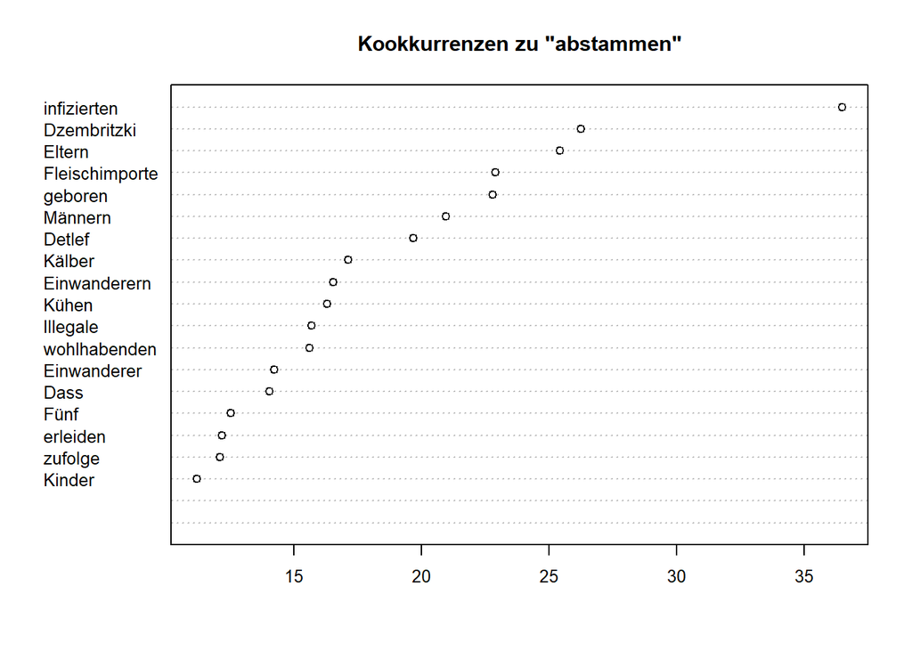

The kwic analysis had also shown that reducing stop words were effective but white noise in the data still exists. Often syntax errors occur and parsing errors from OCR. That is, there is occur-ring information from interjections although there were logically excludes within the function options, or quotation marks and slashes are included without content, as well as there are occur-ring problems with line breaks and the dash for syllabification. To reduce this noise in further steps of analysis, the textclean package will be used.

*Table 5: Permutations of [Ii]us and white noise from interjections and syntax.*

|  | parliamentary_group | speaker | date | url | left | node | right |
| --- | --- | --- | --- | --- | --- | --- | --- |
| 1 | GRUENE | Cem Özdemir | 1996-02-08 | http://webarchiv.bundestag.de/archive/2005/1205/bic/plenarprotokolle/pp/1996/13086a.zip | sollten die deutsche Staatsbürgerschaft auch durch Geburt im Bundesgebiet ( | ius | soli ) erwerben können . Doppelstaatsbürgerschaften sollten verstärkt zugelassen werden |
| 2 | GRUENE | Cem Özdemir | 1996-02-08 | http://webarchiv.bundestag.de/archive/2005/1205/bic/plenarprotokolle/pp/1996/13086a.zip | haben , sind Einbürgerungserleichterungen längst überfällig . Die Ergänzung des | ius | sanguinis durch das ius soli sowie die Hinnahme von Mehrstaatigkeit |
| 3 | GRUENE | Cem Özdemir | 1996-02-08 | http://webarchiv.bundestag.de/archive/2005/1205/bic/plenarprotokolle/pp/1996/13086a.zip | längst überfällig . Die Ergänzung des ius sanguinis durch das | ius | soli sowie die Hinnahme von Mehrstaatigkeit sind international bewährte Lösungswege |
| 4 | FDP | Cornelia Schmalz-Jacobsen | 1997-01-17 | http://webarchiv.bundestag.de/archive/2005/1205/bic/plenarprotokolle/pp/1997/13152a.zip | hätten , wenn wir im Staatsangehörigkeitsrecht das Geburtsrecht , das | Ius | soli , für die hier geborenen Kinder hätten . ( |
| 5 | GRUENE | Kerstin Müller | 1999-03-19 | http://webarchiv.bundestag.de/archive/2005/1205/bic/plenarprotokolle/pp/1999/14028a.zip | gemeinsam tun - für gesellschaftliche Mehrheiten kämpfen , um das | ius | soli pur , ohne das Optionsmodell , zu bekommen . |
| 6 | SPD | Christine Lambrecht | 1999-03-19 | http://webarchiv.bundestag.de/archive/2005/1205/bic/plenarprotokolle/pp/1999/14028a.zip | Union und in den meisten demokratischen Ländern der Welt gültige | Ius | soli , das Territorialprinzip , an seine Seite . Künftig |
| 7 | PDS | Evelyn Kenzler | 1999-05-07 | http://webarchiv.bundestag.de/archive/2005/1205/bic/plenarprotokolle/pp/1999/14040a.zip | jedoch gewesen , ausgehend von einer Grundgesetzänderung zur Einführung des | Ius | soli und zur Abschaffung der unsäglichen Bestimmung über die '' |
| 8 |  | Günther Beckstein | 1999-05-07 | http://webarchiv.bundestag.de/archive/2005/1205/bic/plenarprotokolle/pp/1999/14040a.zip | kann man politisch streiten . Aus meiner Sicht ist das | Ius | soli aber nicht etwa das modernere Recht . Die Zufälligkeit |
| 9 |  | Günther Beckstein | 1999-05-07 | http://webarchiv.bundestag.de/archive/2005/1205/bic/plenarprotokolle/pp/1999/14040a.zip | Bindungen fortwirken . Deswegen kann ich nur sagen : Das | Ius | soli ist nicht etwa das modernere Recht ; vielmehr ist |
| 10 |  | Günther Beckstein | 1999-05-07 | http://webarchiv.bundestag.de/archive/2005/1205/bic/plenarprotokolle/pp/1999/14040a.zip | Abkömmlinge hat , vererbt nach dem von Ihnen so abgelehnten | Ius | sanguinis das Staatsangehörigkeitsrecht . Selbst dessen Abkömmlinge werden wiederum mit |

[output cut: 27 more lines]

The evaluation shows, stemming is not always an adequate method for retrieval search words because of various meanings in different contexts of special lexemes from a word, like *abstammen* and the reference to stockbreeding and DNA-analysis. Plus, some search words are used to refer to different legal concepts like *Optionsmodell* or are also used in a different sense as metaphors like *Doppelpass* and the reference to soccer, however, only in one case, hence it was added to the dictionary because of its theoretical conceptional relevance. In case of *Optionsmodell* it is an ordinary compound from two very common words: option and model, used in various contexts thus it was excluded. However, those information reductions are compensated by other included search words which often co-occur with these ones excluded.

### LDA cross-validation

For cross-validation Latent Dirichlet Allocation was used. Those terms included in the dictionary can by compared and missing values can by identified and admitted. A valid dictionary can later be used for sampling relevant documents regarding the citizenship discourse by using this method. Evaluating the first 300 terms from topic model 133 had shown that the topic model not only refers to citizenship aspects.

*Table 6: Terms referring citizenship from LDA topic modelling*

**terms (stochastical)**

- Staatsangehörigkeit(sgesetz/-es), Einbürgerung, Staatsangehörigkeitsrecht(s/es), Optionspflicht, Pass,
- Optionsmodell, Staatsbürger(schaft/-en), Staatsangehörigen, doppelt(e/en), (nur als n-gram), Paß,
- Staatsbürgerschaftsrecht, Staatsbürgerschaft(srecht), Mehrstaatigkeit, Einbürgerungen,
- Mehrstaatlichkeit, eingebürgerten, Staatsangehörige, einbürgern, Staatsangehörigkeiten,
- Ausländergesetzes, Abschiebung, Optionszwang, Einbürgerungstest, Einbürgerungszahlen, Aufenthalt,
- Optionsmodells, Doppelstaatler, abgeschoben, Doppelpaß, Ausländergesetz, Staatsangehöriger,
- Doppelpass, soli, Staatsbürgern, Pässe

This is, in the linguistic dimension of citizenship it is not only used as a single topic rather than as a complex compound to other issues from *Ausländerpolitik* like Ethnic German resettlers, asylum or family re-unification, as well as deportation. Subsequently, the topic model is a topic of Foreigner´s law. This is hardly surprising for the legal compounding of these aspects. In Germany many regulations are supplemental and special provisions of law are defined subsequently. Those unambiguous terms referring to the citizenship discourse were also taken from the topic modelling and added to the dictionary (see Table 7).

*Table 7: Sorted dictionary adapted from Green (2004:2) (validated)*

```
##                        actors              issues
## 1            [Dd]oppelstaat.*   .*[Aa]us.bürger.*
## 2              [Mm]ehrstaat.*   .*[Ee]in.bürger.*
## 3         .*[Ss]taatsbürger.*    Doppelpa(ss|ß).*
## 4 .*[Ss]taats(an|zu)gehörig.*            Pa(ss|ß)
## 5             [Ss]taatenlos.* [Oo]ptionspflicht.*
## 6                               [Oo]ptionszwang.*
##                                                                                  norm
## 1                                                                        Blutsrecht.*
## 2                                                            Geburts(recht|prinzip).*
## 3 "[Ii]us" "soli"', '"[Ii]us" "sanguinis"', '"[Jj]us" "soli"', '"[Jj]us" "sanguinis"'
## 4                                                        Abstammungs(recht|prinzip).*
## 5
## 6
```

## Conclusion

The paper could present a cross-validation of a deductively formulated dictionary by using the *polmineR* package and the offered corpus GermaParl. It could be shown that conceptional specification is a necessity to formulate an adequate dictionary for a theoretical conducted analysis of a construct like citizenship. Citizenship thereby is one policy field of *Ausländerpolitik* in Germany and defines how is in-peer and out-peer it refers to different concepts of nation, identity and descent. Not every word does refer unambiguously to citizenship. To guarantee the disambiguity and contextuality of definitional citizenship aspects those words that not only refer to this citizenship aspects was excluded from the dictionary. The other stated policy fields asylum, flight, family re-unification, deportation and Ethnic German resettlement were also included within the topic modelling because of the legal incorporation of them. In the step of cross-validation with LDA the topic model detected some more words as the qualitative analysis had provided. Relevant terms from the topic model were therefore also validated per checking the context (qualitative and quantitative) to guarantee disambiguity. Words from the topic model which refer to citizenship aspects were integrated in the dictionary consequently. Information reductions, through the loss of some search words that do not refer to citizenship only, are compensated by other included search words which often co-occur with these ones excluded. The dictionary thus can be used as a reliable and valid method for sampling those documents referring the unambiguous citizenship discourse for further analyses.

(some 2500 words without citation, tables and figures)

## References

- Baker, P., 2006. Using Corpora in Discourse Analysis. London, New York: Continuum.
- Baker, P., et al., 2008. A useful methodological synergy?: Combining critical discourse analysis and corpus linguistics to examine discourses of refugees and asylum seekers in the UK press. Discourse & Society, 19 (3), 273–306.
- Berry, M., Garcia-Blanco, I., and Moore, K., 2016. Press coverage of the refugee and migrant crisis in the EU: A content analysis of five European countries. [Project Report]. Geneva: UNHCR.
- Blaette, A., 2016. polmineR.
- Bloemraad, I., Korteweg, A., and Yurdakul, G., 2010. Staatsbürgerschaft und Einwanderung: Assimilation, Multikulturalismus und der Nationalstaat. In: G. Yurdakul and Y.M. Bodemann, eds. Staatsbürgerschaft, Migration und Minderheiten: Inklusion und Ausgrenzungsstrategien im Vergleich. Wiesbaden: VS Verlag für Sozialwissenschaften / GWV Fachverlage GmbH, Wiesbaden, 13–46.
- BMI Bund, 2019a. Einbürgerung [online], Bundesministerium des Innern, für Bau und Heimat. Availa-ble from: https://www.bmi.bund.de/DE/themen/verfassung/staatsangehoerigkeit/einbuerger-ung/einbuergerung-node.html [Accessed 8 Jul 2019].
- BMI Bund, 2019b. Staatsangehörigkeit [online], Bundesministerium des Innern, für Bau und Heimat. Available from: https://www.bmi.bund.de/DE/themen/verfas-sung/staatsangehoerigkeit/staatsangehoerigkeit-node.html;jses-sionid=AE97B9769E479B9D3D9C80D1B5A62BCA.1_cid287 [Accessed 8 Jul 2019].
- Bommes, M., 2000. Migration und Lebenslauf: Aussiedler im nationalen Wohlfahrtsstaat. Sozialwis-senschaften und Berufspraxis, 23 (1), 9–28.
- Boomgaarden, J.G. and Vliegenthart, R., 2009. How news content influences anti-immigration attitudes: Germany, 1995-2005. European Journal of Political Research (48), 516–542.
- Brubaker, R., 1992. Citizenship and nationhood in France and Germany. Cambridge, Mass. u.a: Har-vard Univ. Press.
- Bubenhofer, N., 2006. Einführung in die Korpuslinguistik: Praktische Grundlagen und Werkzeuge [on-line]. Zürich, Mannheim, Dresden, ZHAW Zurich University of Applied Sciences. Availa-ble from: https://www.bubenhofer.com/korpuslinguistik/kurs/index.php?id=statistik_signif-ikanzLLR.html [Accessed 8 Jun 2019].
- Budge, I., 2015. Issue Emphases, Saliency Theory and Issue Ownership: A Historical and Conceptual Analysis: [Abstract]. West European Politics, 38 (4), 761–777.
- Burke, E., Canavan, F., and Payne, E.J., 1999. Select works of Edmund Burke: A new imprint of the Payne edition. Indianapolis, IN: Liberty Fund.
- DWDS, 2019. Nation [online], Digitales Wörterbuch der deutschen Sprache. Availa-ble from: https://www.dwds.de/wb/Nation [Accessed 1 Jul 2019].
- Dzankic, J., 2016. Migration, citizenship and post-national membership. In: A. Triandafyllidou, ed. Routledge Handbook of Immigration and Refugee Studies. New York, NY: Routledge, 163–168.
- Entman, R., 1993. Framing: Towards clarification of a fractured paradigm. Journal of Communication, 43 (4), 51–58.
- Foucault, M., 2016. Überwachen und Strafen: Die Geburt des Gefängnisses. 16th ed. Frankfurt am Main: Suhrkamp.
- Green, S., 2004. The politics of exclusion: Institutions and immigration policy in contemporary Germany. In: C. Jeffery and C. Lees, eds. Issues in German Politics. Manchester: Manchester University Press. Esser, H., 1993. Soziologie.: Allgemeine Grundlagen. Frankfurt a. M.: Campus Verl.
- Gries, T.S., 2009. Quantitative Corpus Linguistics with R: A Practical Intoduction: Taylor & Francis.
- Habermas, J., 1993. Justification and application: Remarks on discourse ethics. Cambridge, Mass: MIT Press.
- Hansen, G., 2001. Die Deutschmachung: Ethnizität und Ethnisierung im Prozess von Ein- und Ausgren-zungen. In: G. Hansen, R. Pfundtner, and N. Wenning, eds. Lernen für Europa. Münster/ New York/ München/ Berlin: Waxmann Verlag GmbH.
- Helbling, M., 2012. Framing Immigration: Varieties of Arguments, Actors and Opportunity Structures. SSRN Electronic Journal.
- Helbling, M., 2013. Validating integration and citizenship policy indices. Comparative European Poli-tics, 11 (5), 555–576.
- Helbling, M., 2014. Framing Immigration in Western Europe. Journal of Ethnic and Migration Studies, 40 (1), 21–41.
- Helfer, L., 2016. Media effects on politicians: An individual-level political agenda-setting experiment. The International Journal of Press/Politics, 21 (2), 233–252.
- Hoffmann, W., Dose, N., and Wolf, D., 2015. Politikwissenschaft. 3rd ed. Konstanz und München: UTB.
- Hunger, U., 2014. Migrations- und Integrationspolitik im europäischen Vergleich: Jahrbuch Migration - Yearbook Migration 2012/2013. Berlin [u.a.]: LIT.
- Ignatow, G. and Mihalcea, R.F., 2017. Text mining: A guidebook for the social sciences. Los Angeles, London, New Delhi, Singapore, Washington DC, Melbourne: Sage.
- Jacobs, D. and Rea, A., 2007. The end of national models? Integration courses and citizenship trajectories in Europe. International Journal on Multicultural Societies (IJMS), 9 (2), 264–283.
- Jellinek, G. and Jellinek, W., 1914. Allgemeine Staatslehre: Algemeine Soziallehre des Staates. 3rd ed. Berlin.
- Joppke, C., 1999. How immigration is changing citizenship: A comparative view. Ethnic and Racial Studies, 22 (4), 629–652.
- Joppke, C., 2007. Beyond national models: civic integration policies for immigrants in Western Europe. Western European Politics, 30 (1), 1–22.
- Katz, E. and Lazarsfeld, P.F., 1955. Personal influence: The part played by people in the flow of mass communications. New York, NY: Free Press.
- Keating, M., 2009. Social citizenship, solidarity and welfare in regionalized and plurinational states. Citizenship Studies, 13 (5), 501–513.
- Korte, K.-R. and Fröhlich, M., 2004. Politik und Regieren in Deutschland. Paderborn: Schöningh.
- Koschyk, H. and Stolz, R., eds., 2001. Alte und neue Deutsche?: Staatsangehörigkeits- und Integrationspolitik auf dem Prüfstand. München: Hanns Seidel Stiftung e.V.
- Kymlicka, W., 1996. Multicultural Citizenship: Oxford University Press.
- Kymlicka, W. and Norman, W., 1994. Return of the Citizen: A Survey of Recent Work on Citizenship Theory; Survey Article. In: P. Singer, ed. Ethics: Oxford University Press, 104–352.
- Michalowski, I., 2004. An Overview on Introduction Programmes for Immigrants in Seven European Member States. Amsterdam.
- Mohr, K., 2005. Stratifizierte Rechte und soziale Exklusion von Migranten im Wohlfahrtsstaat / Strati-fied Rights and Social Exclusion of Migrants in the Welfare State. Zeitschrift für Soziologie, 34 (5), 219.
- Reichel, D., ed., 2011. Staatsbürgerschaft und Integration: Die Bedeutung der Einbürgerung für MigrantInnen. Wiesbaden: VS Verlag für Sozialwissenschaften / Springer Fachmedien Wiesbaden GmbH, Wiesbaden.
- Schmitz-Vardar, M., 2018. Regionale Differenzen in der gesellschaftlichen Integration. [submitted cur-rently not published].
- Soysal, Y.N., 1994. Limits of Citizenship: Migrants and Postnational Membership in Europe: University of Chicago Press.
- Soysal, Y.N., 1997. Limits of citizenship: Migrants and postnational membership in Europe. 2nd ed. Chicago u. a.: Univ. of Chicago.
- Streeck, W. and Thelen, K., eds., 2005. Beyond Continuity: Institutional Change in Advanced Political Economies. Oxford, UK: Oxford Univ. Pr.
- Tibi, B., 2002. Islamische Zuwanderung: Die gescheiterte Integration. Stuttgart, München: Deutsche Verlags-Anstalt GmbH.
- Tsebelis, G., 1995. Decision Making in Political Systems: Veto Players in Presidentialism, Parliamentarism, Multicameralism and Multipartyism. British Journal of Political Science [online], 25 (3), 289–325. Available from: http://www.jstor.org/stable/194257.
- Wlezien, C., 2005. On the salience of political issues: The problem with ‘most important problem’. Electoral Studies, 24 (4), 555–579.
- Worbs, S., 2008. Die Einbürgerung von Ausländern in Deutschland: Integrationsreport. Working Paper 17. “Integrationsreport” Teil 3: Forschungsgruppe des Bundesamtes für Migration und Flüchtlinge.

## Statutory declaration

I herewith declare that I, Kevin Glock, Koloniestraße 158, 47057 Duisburg, Matriculation number: 30 52 487, have composed the present thesis myself and without use of any other than the cited sources and aids. Sentences or parts of sentences quoted literally are marked as such; other references regarding the statement and scope are indicated by full details of the publications concerned. The thesis in the same or similar form has not been submitted to any examination body and has not been published. This thesis was not yet, even in part, used in another examination or as a course performance.

Kevin Glock Saturday, 29 June 2019

## Appendix

### Code

| #### “.*[Aa]us.bürger.*” |
| --- |

```r
kwic(
  "GERMAPARL",
     query= '".*[Aa]us.*bürger.*"',
     left= 10, right= 10, cqp= TRUE,
     s_attribute= c(
       "parliamentary_group", "speaker", "date", "url"),
     interjection = FALSE, regex = TRUE) %>%
highlight(
     lightgreen= c(
        "geflohen", "geflohene", "Wehrdienstes", "PaÃ", "Menschen", "DDR",
        "Optionskinder", "Bestrebungen", "Rentenleistungen", "VermÃ¶genswerte",
        "Auskunft", "Vertrauensschutz", "reformieren", "doppelte", "StaatsbÃ¼rgerschaft",
        "tÃ¼rkische", "EU-BÃ¼rgerinnen", "ausgereist", "schÃ¤ndliche", "EntscheidungsmÃ¶glichkeit", "staatenlose",
        "Baath-Regimes", "tagtÃ¤glich", "zwangsweise", "Enteignung", "Tschechoslowakei", "Dekrete", "Unrecht",
        "Benes-Dekrete", "Vertreibung", "Sudetendeutschen", "Exzesse", "unschuldig", "Leid", "zugefÃ¼gt", "ehemaligen",
        "ErklÃ¤rung", "Bundesregierungen", "Domaschk", "TÃ¼rkei", "EinschlÃ¤gige", "Vertei", "unschuldiges", "StaatsangehÃ¶riger",
        "Wehrdienstes", "EinbÃ¼rgerungen", "tÃ¼rkischer", "Abschiebungen", "abgestellt", "vornimmt", "beeeinflussen", "erteilen",
        "angesprochenen", "unvermindert", "anhÃ¤lt", "freigekaufte", "zermÃ¼rbendes", "HÃ¤ftlinge", "Westen", "zugeleitet",
        "Abschaffung", "GebÃ¼hren", "StaatsangehÃ¶rigkeit", "entlassen", "Annahme", "verlangt", "Verlieren",
        "Kriminellen", "Sachverhalte", "KreiÃsaal", "Mehrstaatlichkeit", "PaÃ", "Willkommenskultur", "zwangsweise",
        "Schwarzen", "HomosexualitÃ¤t", "Fehlentwicklung", "Letztes", "Ã¼berwiegende", "erworben", "Rassismus", "abschieben",
        "abgeschoben", "Abschiebung", "facto", "doppelte", "begangen", "schweren"),
      regex = FALSE, interjection = FALSE
      )
```

| #### ".*[Ee]in.*bÃ¼rger.*" |
| --- |

```r
words1 <- c("StaatsangehÃ¶rigkeit", "erleichterte", "StaatsbÃ¼rgerschaft", "Integration", "Hinnahme",
           "erleichtern", "doppelten", "Erleichterung", "Integrationsprozesses", "Migranten",
           "doppelte", "Mehrstaatigkeit", "erleichterten", "Regelanfrage", "Voraussetzungen",
           "HÃ¼rden", "Rechtsanspruch", "Erleichterungen", "AuslÃ¤nder", "lassen",
           "EinbÃ¼rgerung", "einbÃ¼rgern", "laÃt", "Einwanderer",
           "StaatsangehÃ¶rige", "diejenigen", "jemanden", "Migranten", "Pass", "Personen",
           "eingebÃ¼rgert", "erfÃ¼llen", "EinbÃ¼rgerungshÃ¼rden", "Vereinspolitik", "integrationsbereiten",
           "Menschen", "Zahl", "EinbÃ¼rgerungen", "gestiegen", "Jahr", "Ausgrenzungen", "Wahlrecht",
           "Ausgrenzung", "umfassend", "erleichtert", "RÃ¼ckgang", "Anschauung", "Gesinnung", "innere",
           "Ã¼berprÃ¼ft", "nachvollziehen", "EinbÃ¼rgerungstests", "testen", "vermeindliche",
           "Geburt", "per", "Fremdenfreundlichkeit", "Duldungs", "islamistisch-fundamentalisitschen",
           "Muslimtest", "Subkultur", "RechtsÃ¤nderung", "StaatsbÃ¼rgerschaftsrecht", "Jahresbeginn", "einhergehende",
           "groÃzÃ¼gige", "StaatsangehÃ¶rige", "eingefÃ¼hrte", "verwehrt", "schlimme", "verletzen",
           "religiÃ¶se", "jemanden", "irgend", "Kriterium", "HÃ¼rden", "IntegrationsbemÃ¼hungen", "befÃ¶rdert",
           "entgegen", "meisten", "passende", "geborenen", "AuslÃ¤nderinnen", "Dokument", "Kanzleramt",
           "Migranten", "Angelegenheit", "erstmals", "irrelevanter", "Ã¼berreichen", "Akt",
           "Migrantinnen", "rechtlich", "stattgefunden", "auzunehmen", "Bundeskanzlerin", "EinbÃ¼rgerungszahlen",
           "naturgemÃ¤Ã", "aufwachsen", "sinkende", "gesellschaftliche", "Ã¼berprÃ¼fen", "rechtlichen", "verlieren", "Teilhabe",
           "EinbÃ¼rgerungsquoten", "Prozentual", "schlechtesten", "stieg", "dreimal", "stÃ¼tzen", "Schweden", "Deutschland",
           "loszutreten", "begrÃ¼Ãenswert", "befÃ¼rwortet", "werben", "einbÃ¼rgern", "grundlegend", "scheitern",
           "hinnehmen", "IdentitÃ¤tsstiftung", "gutheiÃen", "kÃ¶nne", "verstanden", "Schulabschluss",
           "bildungsfernere", "verschiedene", "Verfassungstreue", "abgefragt", "Inwiefern", "Schulsystem",
           "durchlaufen","Tests", "Frage", "Inwieweit", "nachweisen", "deutschen", "verschiedene",
           "EinbÃ¼rgerungsbewerberinnen", "bewerber", "vermeiden", "BundeslÃ¤nder", "EinbÃ¼rgerung", "novellierte",
           "Ermutigung", "Beauftragte", "Gesetzteslage", "aufklÃ¤ren", "KÃ¼rze", "bemÃ¼hen", "Integrationsgipfeln", "durchaus",
           "Mehrstaatigkeit", "lebende", "Festhalten", "verkÃ¼rzt", "ideologische", "Fristen",
           "Selbstverpflichtung", "GebÃ¼hren", "VerschÃ¤rfung", "Vermeidung", "Themas", "Belehrungsbedarf",
           "willkommen", "stehe", "derjenige", "SPD-Bundestagsfraktion", "verankert",
           "EinbÃ¼rgerungskurse", "angeforderte", "vorgeschlagenen", "geplante", "absurde", "ZÃ¼ge",
           "verweise", "aktuellen", "StaatsbÃ¼rgerkursen", "Leibe", "rÃ¼cken", "Ã¼berprÃ¼fen",
           "Gesinnungstests", "einbÃ¼rgerungswilligen", "gehend", "Irre", "nÃ¼tzen",
           "bilaterales", "Austausch", "verhandeln", "Abkommen", "abzulegen", "Grundgesetz", "eingefÃ¼hrt",
           "Fluss", "abgearbeitet", "abzubauen", "debattieren", "beklagt", "EinbÃ¼rgerungsverfahren",
           "human", "beseitigt", "EinbÃ¼rgerungshindernis", "gestaltet", "beseitigten", "gestalten", "Gesetzeswerk",
           "wirkungsvoll", "InnenausschuÃ", "Placebo", "vermeidet", "Optionsmodell", "bekommt", "Kinderausweis",
           "Unionsentwurfes", "VerlustgrÃ¼nde", "Kinder", "auslÃ¤ndischen", "AuslÃ¤ndergeneration", "beantragt",
           "eigentliche", "Gutschein", "Alternative", "vorzuenthalten", "Modell", "auffÃ¼hrt", "Optionsmodells",
           "wertlos", "Irrglauben", "Leistungen", "derjenigen", "Ausnhamen", "gemeint", "Ziffern", "Seminar",
           "Gesetzestext", "Ã¼berfÃ¼hrt", "geltendes", "veranstalten", "abhÃ¤ngen", "Interpretation", "vorlesen",
           "VerkÃ¼rzung", "Territorialprinzips", "AnspruchseinbÃ¼rgerungen", "Vertriebene", "HÃ¤rtefÃ¤lle",
           "Kernpunkte", "hinlÃ¤nglich", "einrÃ¤umt", "Aussiedler", "Ausnahmeregelung", "verkÃ¼rzen", "Erwachsene", "verkÃ¼rtzt",
           "verbesserte", "deutlichen", "wirkliche", "Stellenwert", "denkt", "ausgehen", "letztlich", "aufgetauchte",
           "KinderstaatszugehÃ¶rigkeit", "verunglÃ¼ckte", "Koalitionsvertrages", "Variante", "jÃ¼ngst", "Aufstockung",
           "Lebensjahr", "sinnvolle", "Rechtslage", "frÃ¼here", "Selbststudium", "AndersglÃ¤ubigen",
           "EinbÃ¼rgerungsvoraussetzungen", "angehobenen", "FuÃballnationalmannschaft", "verfassungsfeindlichen",
           "Rechtstreue", "erfragen", "aufnehmenden", "EinbÃ¼rgerunstest", "berÃ¼cksichtigt", "Verfassungsordnung",
           "Potenzials", "sachgerechter", "Hinwendung", "skandalÃ¶sen", "Gesinnungstest", "Sprachniveau", "miserable",
           "representative", "ausdehnen", "Vorschrift", "Befragung", "abwarten", "absurd", "erfÃ¼llen", "Sprachkenntnisse",
           "erschwert", "Staats-angehÃ¶rigkeit", "EinbÃ¼rgerungsverhalten", "Hildesheimer", "anforderungen",
           "EinbÃ¼rgerungsantrag", "ausreichende", "annehmen", "Absenkung", "EinbÃ¼rgerungsbewerber",
           "EinbÃ¼rgerungsbehÃ¶rden", "Ermessensentscheidung", "LoyalitÃ¤t", "Untersuchungen",
           "EinbÃ¼rgerungsvoraussetzungen", "Forschungsgruppe", "Optionsregelung", "Ã¼bertriebenen",
           "integrationspolitischen", "Betrachtet", "unionsgefÃ¼hrten", "vernachlÃ¤ssigt",
           "auswirken", "wider", "wissenschaftliche", "umfasst", "allgemein", "vergleichbar", "bÃ¼rokratischen",
           "stehnden", "Aufwand", "FÃ¤lle", "angeht", "Regelanfrage", "EinbÃ¼rgerungshindernisse",
           "verfassungsschutz", "Strafvorschrift", "RechtsansprÃ¼che", "Ermessensregelungen",
           "BehÃ¶rdenpraxis", "Ayslstatus", "TÃ¤uschungsversuche", "bundesweit", "Gebrauchsanweisung",
           "Bundeseinheitliche", "Rechtssystematik", "Optionspflichtige", "FlÃ¼chtlinge", "Optionsregelung",
           "Bundeamts", "reprÃ¤sentativen", "MitbÃ¼rgern", "befragt", "Bundesamt", "belegen",
           "baden-wÃ¼rttembergischen", "erhebliche", "Wissensfragen", "handhabenden",
           "EntlassungsbemÃ¼hungen", "GesprÃ¤chsleitfaden", "Landesregierung", "EinbÃ¼rgerungsvoraussetzungen",
           "lahmlegen", "ansÃ¤ssiger", "unkomplizierte", "Aufweichen", "Mehrstaatlichkeit", "entwertet",
           "ErmÃ¶glichung", "Aufweichung", "Briten", "generelle", "weiten", "drittens", "akzeptiert",
           "weiten", "Teilen", "akzeptiert", "BevÃ¶lkerung", "Explosionsstoffgesetz", "Staatsgesellschaft",
           "zurÃ¼cknÃ¤hme", "dazuzugehÃ¶ren", "integrationspolitisch", "Iraner", "erleichterte", "vertiefte", "SpÃ¤taussiedlern",
           "verschweigt", "Lebenspartner", "kleinreden", "Zukunftschancen", "HerkunftsstaatsangehÃ¶rigkeit",
           "MittelmaÃ", "extremen", "bescheinigt", "folgendermaÃen", "Integrationspolitik", "abzugeben", "europÃ¤isches",
           "europÃ¤ischen", "schlechtesten", "Vergleich", "EinbÃ¼rgerungsrate", "Prozentual", "Neunte",
           "Eu-AuslÃ¤nder", "woraus", "StaatsangehÃ¶riger", "tÃ¼rkischer", "resultieren", "Statistischen",
           "niedriegsten", "Deutschland", "verantwortungslose", "dreimal", "Migrationshintergrund",
           "dopplete", "differenziert", "niedrige", "normal", "Niveau", "UnterhaltungsfÃ¤higkeit",
           "EinbÃ¼rgerungsbewerbern", "AuslÃ¤nderin", "eingebÃ¼rgerten", "unabhÃ¤ngig", "Straflosigkeit",
           "entlarvend", "rechtmÃ¤Ãig", "verkÃ¼rzt", "eigenstÃ¤ndigen", "generelle", "MitbÃ¼rger",
           "erworben", "lebenden", "Quizshow", "Hauptschulabschluss", "Test", "bestanden",
           "StaatsangehÃ¶rigkeitsgesetz", "EinbÃ¼rgerungstest", "Teilnahme", "Staatsaufbau",
           "bestehen", "abgelegt", "ablegen", "Tests", "Orientierungskurses", "partizipierenden",
           "HÃ¼rde", "Schulabschluss", "testweise", "abschreckend", "Ausgestaltung", "Nichtvorliegens",
           "beteiligen", "Zahlen", "PrÃ¼fungsfragen", "beantworte", "Orientierungskursen", "Erfolgsschlager",
           "Absolvierung", "Schulferien", "albernen", "Pools", "DÃ¤monisierung", "wirken", "Teilnahme",
           "Voraussetzung", "IMK", "vorbereitenden", "Test", "IMK-Beschlusses", "Lehrstoff", "Selbststudium",
           "Teilnahme", "IMK-Beschluss", "Orientierungskursen", "betraute", "angeforderte", "geplante",
           "Planung", "Gesinnungstest", "organisiert", "Vorbereitung", "EinbÃ¼rgerungsbewerber",
           "Schulferien", "Curriculum", "EinbÃ¼rgerungsoffensive", "Einwanderungsoffensive", "sprechen",
           "vornehmen", "felsenfesten", "Pappkameraden", "dezidiert", "Ã¼berwiegende", "unmiÃverstÃ¤ndlichen",
           "NeubÃ¼rger", "nachdrÃ¼cklichen", "verlangen", "zugleich", "SelbstlÃ¤ufer", "dahinter", "steckt",
           "Augsburg", "EinbÃ¼rgerungszahlen", "zurÃ¼ckgegangen", "EinbÃ¼rgerung", "dramatisch", "gesunken",
           "FÃ¼nftel", "sinkende", "Durchschnittswerte", "Inkrafttreten", "Tiefstand", "EinbÃ¼rgerungen",
           "RÃ¼ckgang", "Jahrzehnts", "FrÃ¼hjahrszeitrÃ¤umen", "reformbedingte", "diametraler",
           "EinbÃ¼rgerungsrechts", "modernes", "Ã¼berprÃ¼fen", "VerschÃ¤rfungen", "Hemmnisse",
           "VÃ¶lkisch", "PKK-KÃ¤mpfer", "getreten", "Belange", "behÃ¶rdliches", "Teilhaberechte",
           "EinbÃ¼rgerungsverfahren", "Erschwernisse", "ebnet", "aufenthaltsrechtliche",
           "strÃ¤uben", "reformierte", "groÃzÃ¼gigsten", "liberalsten", "Integrationsleistung",
           "Drittstaatler", "nachweisbare", "Unverzichtbar", "Projektarbeit", "kommunales",
           "HÃ¼rden", "geringe", "Unzumutbarkeiten", "Eingewanderte", "AuslÃ¤nderfragen",
           "EinbÃ¼rgerungszahlen", "vorzuenthalten", "Arbeitskreises", "eingebÃ¼rgert",
           "unseres", "Test", "HerzstÃ¼ck", "WiderstÃ¤nde", "liberalen", "erlangen",
           "insbesondere", "Votum", "demokratischer", "Bundesamt", "zusammengestellten",
           "Mehrstaatigkeit", "weitergeleitet", "Statistische", "Statistischen",
           "Erstellung", "deutschem", "eindrucksvoll", "Migrationshintergrund",
           "generell", "tÃ¼rkischstÃ¤mmigen", "Plenum", "einbringen", "grÃ¶Ãte",
           "StaatsangehÃ¶rigkeitsrecht", "StaatsangehÃ¶rigkeitsrechts", "enthaltenen",
           "umfassender", "Integrationspolitik", "Bundesregierung", "einladende",
           "Einwanderungspolitik", "eingebÃ¼rgert", "scheut", "plÃ¤dieren", "modernes", "Sachverhalt",
           "sanguinis", "Rennpferd", "ius", "Anwerbeabkommens", "VerstÃ¶Ãen", "ablehne", "fÃ¤llige",
           "Lebensmittelpunkt", "EinbÃ¼rgerungen", "gleichberechtigten", "ungeachtet", "enthaltenden",
           "umfassender", "Intregationspolitik", "Bundesregierung", "korregiert", "wesentlichen",
           "entwickelt", "Zuspitzung", "KomplexitÃ¤t", "Problematik", "dient", "symbolischen", "senken",
           "Aufenthaltsfristen", "verzichten", "symbolisches", "EinbÃ¼rgerungstest", "KrÃ¶nung", "betrÃ¤chtlich",
           "vereinfachen", "verkÃ¼rtzt", "EU-Staaten", "insoweit", "Bellevue", "Schloss", "BundesprÃ¤sident",
           "Rede", "eingebÃ¼rgert", "US-amerikanische", "bemerkenswerte", "Gauck", "Roth", "Winkler", "Wulff", "Maas", "anlÃ¤sslich",
           "Merkel", "Gewicht", "letztes", "eingeladen", "Domenico", "Inlandsaufenthaltes",
           "anzufragen", "EinbÃ¼rgerungsvoraussetzungen", "AuslÃ¤nders", "Costa", "MutmaÃungen",
           "Bundesverwaltungsgerichtes", "beschieden", "Motiven", "angegeben", "Besten", "AuslÃ¤ndern",
           "unterliegt", "stellen", "Einwanderungsgesellschaft", "menschennahen", "einladenden", "modernen",
           "gleichrangige", "leichtfertige", "skurril", "Zauberwort", "EingleiderungsmaÃnahmen", "intakten",
           "abschreckende", "gerecht", "GesetzesbegrÃ¼ndung", "puncto", "FDP-Antrag", "Politikerinnen",
           "Integrationspolitik", "Sprachkenntnisse", "materielle", "Zwang", "Vorteile", "verfÃ¼gen",
```

```r
           "rechtliche", "Ã¼berzeugend", "alt", "Grindel", "praktisch", "Rentner", "angeblich", "Migranten",
           "StaatsbÃ¼rgerschaft", "Hinnahme", "AuslÃ¤nder", "EinbÃ¼rgerung",
           "Mehrstaatigkeit", "Voraussetzungen", "Lebensjahr", "StaatsangehÃ¶rigkeit", "Begriff",
           "FlÃ¼chtlingsstatus", "Iraner", "el-Masri", "leben", "einbÃ¼rgern",
           "unkompliziert", "zehnte", "AuslÃ¤nderinnen", "StaatsangehÃ¶rige", "EinbÃ¼rgerungsgesetz",
           "AuslÃ¤nderzentralregister", "sozioÃ¶konomische", "BildungsabschlÃ¼sse", "Lebensunterhalts", "rassistisch",
           "gÃ¼nstigere", "VerschÃ¤rfungen", "Einfach", "festzuschreiben", "Merkmale", "Befund", "ausweisen", "diskriminiert",
           "Nachhinein", "erfolgreicher", "Statistiken", "TÃ¼rken", "Pass", "TÃ¼rkin", "eingebÃ¼rgerten", "lebenden",
           "Deutschen", "AuslÃ¤ndern", "TÃ¼rkischstÃ¤mmigen", "NichtseÃhaften", "GÃ¼terstÃ¤nden", "deutschen",
           "EinbÃ¼rgerungsanspruch", "Abstammungsprinzip", "nachziehende", "zugewanderten", "tÃ¼rkischstÃ¤mmigen",
           "TÃ¼rkinnen", "trifft", "Studie", "Doppelstaatler", "Prozent", "Beibehaltung", "anforderungen",
           "Geburtsjahrgang", "separat", "Praxis", "Nachzug", "alten", "Nunmehr", "durchgefÃ¼hrte", "ausblenden", "Deutschland",
           "formale", "Menschen", "EinbÃ¼rgerung", "Kinder", "Jahre", "AuslÃ¤nder", "Begriff", "Hinnahme", "leben", "Personen",
           "Zahl", "Mehrstaatlichkeit", "Voraussetzungen", "Prozent")

kwic(
  "GERMAPARL",
  query= '".*[Ee]in.*bürger.*"',
  left= 10, right= 10, cqp= TRUE,
  s_attribute= c(
    "parliamentary_group", "speaker", "date", "url"),
  interjection = FALSE, regex = TRUE
  ) %>%
highlight(
  lightgreen = words1,
  regex = FALSE, interjection = FALSE
  )
```

| #### "[Ss]taatenlos.*" |
| --- |

```r
kwic(
  "GERMAPARL",
    query= '"[Ss]taatenlos.*"',
    left= 10, right= 10, cqp= TRUE,
    s_attribute= c(
      "parliamentary_group", "speaker", "date", "url"),
    interjection = FALSE, regex = TRUE) %>%
highlight(
    lightgreen= c(
      "staatenlose", "Kurden", "Syrien", "StaatangehÃ¶rige", "Palistinenser", "doppelt", "Baath-Regimes",
      "radikalisierten", "Puntland", "ausgebÃ¼rgert", "konsularische", "Rechtsnorm", "zerfallenden", "Personen",
      "stammende", "hinfÃ¤llig", "leben", "gescheiterte", "abgeschobenen", "RÃ¼ckfÃ¼hrung",
      "Syrerinnen", "Syrern", "gewÃ¶hnlichen", "DrittstaatenangehÃ¶rigen", "demgegenÃ¼ber", "Ãbereinkommens",
      "Abschiebung", "Aufenthalt", "vermeintlich", "Roma", "Text", "Minestnormen", "anderweitig", "Status",
      "Schutz", "Anerkennung", "FlÃ¼chtlinge", "internationalen", "Ausreisepflichtiger", "RÃ¼ckÃ¼bernahme",
      "Damaskus", "allerletzte", "FlÃ¼chtlings", "AuslÃ¤nderbehÃ¶rden", "StaatangehÃ¶rigen",
      "FlÃ¼chtlingskonvention", "DurchbefÃ¶rderung", "DrittstaatenangehÃ¶riger", "Komponenten",
      "Somit", "Ãbernahme", "eigener"),
    regex = FALSE, interjection = FALSE
    )
```

| #### "[Ss]taatsbürger.*" |
| --- |

```r
words2 <- c(
    "Kosovo", "Wahlen", "kosovarisch-serbischen", "beteiligen", "binationalen", "Stimmabgabe", "EU-BÃ¼rger", "serbischen", "lebenden", "aufgerufen",
    "geboren", "Mutter", "bekommt", "Kind", "geschehen", "Terrororganisation", "StaatsbÃ¼rgerschaft", "Verlust", "kÃ¤mpfen", "nenne",
    "Ausland", "Lorenzo", "Giovanni", "einzubÃ¼rgern", "bringt", "di", "Hinnahme", "Probleme", "angeklungen", "durften", "aufhalten",
    "StaatsangehÃ¶rigkeit", "eingebÃ¼rgerte", "EingebÃ¼rgerten", "Listen", "cleveren", "illegalen", "StaatsangehÃ¶rigkeiten", "LoyalitÃ¤t", "PÃ¤sse",
    "Bekleidungssitten", "illegaler", "Spannungen", "hingenommen", "Haydar", "Machokultur", "Mehrstaatler", "heranzÃ¼chten", "Ernstes", "terroristische",
    "Problemlos", "deutsches", "Penner", "Millionen", "Fehdehandschuh", "StaatsangehÃ¶rigkeit", "zwei", "Personalausweisgesetztes",
    "AnspruchseinbÃ¼rgerung", "hingeworfen", "groÃangelegte", "LoyalitÃ¤tskonflikte", "geraume", "muÃt", "StaatsangehÃ¶rigkeitsgesetz", "Konfliktfall",
    "Diktion", "Gegenargument", "Mikrozensus", "denkbare", "StaatsangehÃ¶riger", "gezielte", "betrÃ¤gt", "19jÃ¤hrigen", "Wehrdienst", "plÃ¶tzlich",
    "leistet", "dritten", "Doppelstaatlichkeit", "Streitpunkt", "hinzunehmen", "Sendboten", "engherzige", "Definieren", "Namentlich", "Ã¼belste",
    "vermÃ¶gensrechtliche", "nÃ¤herzukommen", "Notwenigkeit", "Mehrstaatlichkeit", "bestimmten", "Paulus", "reformschritt", "Damaskus", "FÃ¤llen",
    "unbegrenzten", "millionenfach", "zerrissen", "millionenfache", "hierdurch", "irgendwelche", "BegrÃ¼ndung", "entstehen",
    "StaatsangehÃ¶rigkeitsrecht", "erwerben", "groÃem", "bietet", "MaÃe", "verfallen", "Irrtum", "Migranten", "privilegiert", "Betreffenden",
    "Integration", "kÃ¶nne", "StaatsbÃ¼rger", "erschwert", "integriert", "Jus", "Adelsprivileg", "politisch", "reaktionÃ¤res", "gleichzeitig",
    "sollen", "StaatsangehÃ¶rigkeit", "Rechtsprinzip", "sanguinis", "frohlocken", "hochkomplexe", "denen", "tÃ¤glichen", "Lebens", "akzeptieren",
    "abgeschlossen", "Nurdeutsche", "Berti", "Vogts", "UnverhÃ¤ltnismÃ¤Ãig", "bestimmten", "Nationalmannschaft", "bereichern", "Ãmtern",
    "Schmalz-Jacobson", "StaatsbÃ¼rger", "Landschaft", "Leitung", "Gerichten", "klarmachen", "Wohnsitz", "Pflichten", "festen", "richten",
    "Rechte", "einfach", "Privileg", "ganz", "generellen", "DoppelstaatsbÃ¼rgerschaft", "erleichterte", "flÃ¤chendeckender", "EinbÃ¼rgerung",
    "betrachtend", "FÃ¼Ãe", "bayrische", "StaatsbÃ¼rgerschaft", "Selin", "Iran", "Schily", "Kopf", "deutsche", "akzeptieren", "AuslÃ¤nderkriminalitÃ¤t",
    "LÃ¤nderinteressen", "entlÃ¤sst", "Freundlichkeit", "Kampfansage", "ius", "soli", "Aufenthaltsstatus", "Bundesgebiet", "erwerben", "Geburt",
    "zugelassen", "Papier", "verstÃ¤rkt", "Erde", "Bundesrepublik", "sogenannte", "LÃ¤ndern", "Deutschland", "abgeschlossen", "vorhandener",
    "RÃ¼cksicht", "Gestatten", "Einzelfall", "Konflikt", "gelöst", "Bundeswehr", "Uniform", "deutsch", "Leitbild", "FÃ¼hrung", "inner",
    "Soldat", "StaatsbÃ¼rger", "StreitkrÃ¤fte", "Prinzip", "tÃ¼rkisch", "Vereinigung", "CDU", "Unterricht", "Bildung", "Recht",
    "Pflicht", "politische", "deutsche", "tÃ¼rkische", "syrische", "auslÃ¤ndische", "Visumpflicht", "britische", "TÃ¼rkei", "iranische",
    "Ausland", "entfÃ¼hrt", "Visumfreiheit", "Kurzaufenthalt", "Aufenthalt", "Deutschland", "Opfer", "AuslÃ¤nder", "FÃ¼rsorgeabkommens",
    "Visafreiheit", "konsularische", "tÃ¼rkischen", "deutschen", "StaatsangehÃ¶rigen", "eigenen", "Staaten", "StaatsangehÃ¶rigkeit",
    "lebenden", "ausreisepflichtigen", "tÃ¼rkischer", "mazedonischen", "Hoheitsgebiet", "serbischen", "Ehegattennachzug", "Mehrstaatigkeit",
    "Ehegatten", "syrischen", "Einreise", "Mitgliedstaats", "deutscher", "tÃ¼rkischer", "Kurzaufenthalte", "Einreise", "Auslieferung", "auslÃ¤ndischer",
    "Evakuierung", "konsularischer", "assoziationsrechtlichen", "befindlicher", "RÃ¼ckfÃ¼hrung", "Rechtsstatus", "Bundesdienststellen",
    "visumfreie", "Gefangentransporte", "Obhut", "eigener")

kwic(
  "GERMAPARL",
    query= '"[Ss]taatsbürger.*"',
    left= 10, right= 10, cqp= TRUE,
    s_attribute= c(
      "parliamentary_group", "speaker", "date", "url"),
    interjection = FALSE, regex = TRUE) %>%
highlight(
    lightgreen= words2,
    interjection = FALSE, regex = FALSE
    )
```

| #### “[Dd]oppel(.*\|[])staat.*” |
| --- |

```r
kwic(
  "GERMAPARL",
    query= c('"[Dd]oppelstaat.*"|"[Dd]oppelt.*" [] "[Ss]taat.*"| "[Dd]oppel.*" "[Ss]taat.*"'),
    left= 10, right= 10, cqp= TRUE,
    s_attribute= c(
      "parliamentary_group", "speaker", "date", "url"),
    interjection = FALSE, regex = TRUE) %>%
  highlight(
    lightgreen= c(
      "Kosovo", "Wahlen", "kosovarisch-serbischen", "beteiligen", "binationalen", "Stimmabgabe",
      "EU-Bürger", "serbischen", "lebenden", "aufgerufen", "geboren", "Mutter", "bekommt", "Kind", "geschehen",
      "Terrororganisation", "Staatsbürgerschaft", "Verlust", "kÃ¤mpfen", "nenne", "Ausland", "Lorenzo",
      "Giovanni", "einzubürgern", "bringt", "di", "Hinnahme", "Probleme", "angeklungen", "durften", "aufhalten",
      "Staatsangehörigkeit", "eingebürgerte", "Eingebürgerten", "Listen", "cleveren", "illegalen",
      "Staatsangehörigkeiten", "Loyalität", "Pässe", "Bekleidungssitten", "illegaler", "Spannungen",
      "hingenommen", "Haydar", "Machokultur", "Mehrstaatler", "heranzÃ¼chten", "Ernstes", "terroristische",
      "Problemlos", "deutsches", "Penner", "Millionen", "Fehdehandschuh", "StaatsangehÃ¶rigkeit", "zwei",
      "Personalausweisgesetztes", "Anspruchseinbürgerung", "hingeworfen", "großangelegte", "Loyalitätskonflikte",
      "geraume", "mußt", "StaatsangehÃ¶rigkeitsgesetz", "Konfliktfall", "Diktion", "Gegenargument",
      "Mikrozensus", "denkbare", "StaatsangehÃ¶riger", "gezielte", "betrügt", "19jährigen", "Wehrdienst",
      "plötzlich", "leistet", "dritten", "Doppelstaatlichkeit", "Streitpunkt", "hinzunehmen", "Sendboten",
      "engherzige", "Definieren", "Namentlich", "übelste", "vermögensrechtliche", "näherzukommen",
      "Notwenigkeit", "Mehrstaatlichkeit", "bestimmten", "Paulus", "reformschritt", "Damaskus", "Fällen",
      "unbegrenzten", "millionenfach", "zerrissen", "millionenfache", "hierdurch", "irgendwelche",
      "Begründung", "entstehen", "Staatsangehörigkeitsrecht", "erwerben", "großem", "bietet", "Maße",
      "verfallen", "Irrtum", "Migranten", "privilegiert", "Betreffenden", "Integration", "könne", "Staatsbürger",
      "erschwert", "integriert", "Jus", "Adelsprivileg", "politisch", "reaktionäres", "gleichzeitig", "sollen",
      "Staatsangehörigkeit", "Rechtsprinzip", "sanguinis", "frohlocken", "hochkomplexe", "denen", "täglichen",
      "Lebens", "akzeptieren", "abgeschlossen", "Nurdeutsche", "Berti", "Vogts", "UnverhÃ¤ltnismäßig", "bestimmten",
      "Nationalmannschaft", "bereichern", "Ämtern", "Schmalz-Jacobson", "Staatsbürger", "Landschaft", "Leitung",
      "Gerichten", "klarmachen", "Wohnsitz", "Pflichten", "festen", "richten", "Rechte", "einfach", "Privileg",
      "ganz", "generellen", "Doppelstaatsbürgerschaft", "erleichterte", "flächendeckender", "Einbürgerung",
      "betrachtend", "Fälle", "bayrische", "Staatsbürgerschaft", "Selin", "Iran", "Schily", "Kopf", "deutsche",
      "akzeptieren", "Ausländerkriminalität", "Länderinteressen", "entlässt", "Freundlichkeit", "Kampfansage",
      "ius", "soli", "Aufenthaltsstatus", "Bundesgebiet", "erwerben", "Geburt", "zugelassen", "Papier", "verstärkt",
      "Erde", "Bundesrepublik", "sogenannte", "Ländern", "Deutschland", "abgeschlossen", "vorhandener", "Rücksicht",
      "Gestatten", "Einzelfall", "Konflikt", "gelöst"),
    regex = FALSE, interjection = FALSE
    )
```

| #### “.*[Ss]taats(ange\|zuge).*” |
| --- |

```r
kwic(
  "GERMAPARL",
    query= '".*[Ss]taats(ange|zuge).*"',
    left= 10, right= 10, cqp= TRUE,
    s_attribute= c(
      "parliamentary_group", "speaker", "date", "url"),
    interjection = FALSE, regex = TRUE) %>%
highlight(
    lightgreen= c(
      "deutsche", "türkische", "syrische", "ausländische", "Visumpflicht", "britische", "Türkei", "iranische",
      "Ausland", "entführt", "Visumfreiheit", "Kurzaufenthalt", "Aufenthalt", "Deutschland", "Opfer", "Ausländer",
      "Fürsorgeabkommens", "Visafreiheit", "konsularische", "türkischen", "deutschen", "Staatsangehörigen",
      "eigenen", "Staaten", "Staatsangehörigkeit", "lebenden", "ausreisepflichtigen", "türkischer", "mazedonischen",
      "Hoheitsgebiet", "serbischen", "Ehegattennachzug", "Mehrstaatigkeit", "Ehegatten", "syrischen", "Einreise",
      "Mitgliedstaats", "deutscher", "türkischer", "Kurzaufenthalte", "Einreise", "Auslieferung", "ausländischer",
      "Evakuierung", "konsularischer", "assoziationsrechtlichen", "befindlicher", "Rückführung", "Rechtsstatus",
      "Bundesdienststellen", "visumfreie", "Gefangentransporte", "Obhut", "eigener", "Haltern", "Österreicher",
      "vorläufige", "Petitionsrecht", "vorgibt", "Einbürgerung", "Geldbeutel", "Erwerb", "unterschreiben",
      "Ausländer", "doppelten", "Letzte", "Konvention", "Entscheidende", "zugehörigkeit", "angekündigten", "sogenannte",
      "Einwanderern", "wollten", "Kinder", "Geburt", "aufgetauchte", "Einbürgerungsgarantie", "Minimallösungen",
      "Schrittchen", "verunglückte", "Totgeburten", "Fehlgeburten", "Meint", "einstmals", "bezweckt", "schwanger",
      "Einführung", "merkwürdigen", "geborene", "schiebt", "Variante", "jüngst", "nötige", "vorhandener", "Rücksicht",
      "Gestatten", "Einzelfall", "Konflikt", "gelöst"),
    regex = FALSE, interjection = FALSE
    )
```

| #### “[Ii]us” |
| --- |

```r
kwic(
  "GERMAPARL",
    query= '"[Ii]us"',
    left= 10, right= 10, cqp= TRUE,
    s_attribute= c(
      "parliamentary_group", "speaker", "date", "url"),
    interjection = FALSE, regex = TRUE) %>%
highlight(
    lightgreen= c(
      "soli", "sanguinis", "Staatsangehörigkeitsrecht", "Abkömmlinge", "moderne", "Geburtsortprinzips",
      "Einwanderungskonzept", "Territorialprinzips", "bello", "geboren", "wilhelminische", "bellum", "fortwirken",
      "Geburtsrechts", "Zufälligkeit", "achtjährigen", "ius", "Territorialprinzip", "Geburtsrecht", "Untersuchung", "trat",
      "ad", "Seitdem", "Neben", "Deutscher", "Staatsbürgerschaftsrechts", "Hinnahme", "Mehrstaatigkeit", "hieraus",
      "Staatsangehörigkeitsrechts", "Doppelstaatsbürgerschaften", "Staatsbürger", "Blutsrecht", "überfällig",
      "Einbürgerungserleichterungen", "Beide", "Soli", "Jus", "tizministerin", "tizministerium", "Fortschrittlich",
      "unechten", "diametralen", "Ãffnung", "Doppelstaatsangehörigkeit", "echtes", "Abkehr", "Richtung", "stoppt", "überzugehen",
      "Justizhaushalt", "Optionsmodell", "liberales", "Arbeitsanreize", "Arbeitnehmerüberlassungsgesetz", "blauen", "geringere",
      "abgelaufen", "Lohnnebenkosten"),
    regex = FALSE, interjection = FALSE
    )
```

| #### "[Oo]ptions(modell\|pflicht).*" |
| --- |

```r
kwic(
  "GERMAPARL",
    query= '"[Oo]ptions(modell|pflicht).*"',
    left= 10, right= 10, cqp= TRUE,
    s_attribute= c(
      "parliamentary_group", "speaker", "date", "url"),
    interjection = FALSE, regex = TRUE) %>%
highlight(
    lightgreen= c(
      "Optionsmodell", "Staatsangehörigkeitsrecht", "Staatsangehörigkeit", "Personengesellschaften",
      "abschaffen", "Betriebssteuer", "Bedenken", "Modell", "Personenunternehmen", "Einbürgerungszusicherung",
      "bürokratischer", "Justizministern", "evaluieren",  "entfristen", "ernstzunehmenden", "entschieden", "Jus",
      "optieren", "rechnet", "Hinnahme", "Abschaffung", "Staatsbürgerschaft", "abgeschafft", "Mehrstaatigkeit",
      "befreit", "abschaffen", "aufgewachsene", "Optionspflicht", "abzuschaffen", "aufgewachsen", "doppelte",
      "Staatsbürgerschaftsrecht", "bundespolitischer", "doppelten", "StaatsangehÃ¶rigkeitsgesetz", "Mehrstaatlichkeit",
      "fordern", "Einführung", "Verfassungsmäßigkeit", "Aydan", "Standordsicherungsgesetztes", "Modell", "einheitliches",
      "Ergeb-nisse", "Per-sonen", "generelle", "Evaluation", "Oberfinanzpräsident", "kardinaler", "anwendbares",
      "läutet", "fordert", "Jelpke", "Geburtsjahrgang", "Optionspflichtigen", "Prozent", "Knapp", "deutsche",
      "Optionspflichtige", "entschieden", "Entscheidungsverhalten", "melderechtlichen", "Zukunftsplanungen",
      "optionspflichtig", "überwiegend", "Fallgruppe", "beinhaltet", "Pass", "Baccalauréat", "Köln-Ehrenfeld",
      "Veli", "geboren", "Matura", "Optionspflichtigen", "französisches", "Herkunftslandes", "jemand", "Österreichische",
      "Hauptschulabschluss", "vollendet", "Uli", "einzeln", "Abitur", "falsches", "Übergangsregelung", "Rot",
      "Grün", "Bundeskanzleramt", "eingeladen", "Ab", "kurzem", "Verwaltungskos", "Eigenmittelbericht",
      "Abfindungsregelungen", "Anrechnungsverfahren", "EU-Haushalts", "Steuerflüchtlinge", "Erweiterungsfähigkeit",
      "Kommissionsbericht", "Einkommenssteuersatz", "Tisch", "Anstiegs", "körperschaftssteuersatz", "durchkommen",
      "Spreizung", "Miarbeiterbeteiligung", "Kommission", "Arbeitsgemeinschaft", "starren", "Kliniken", "zielen",
      "Optionspflichtverlängerungs", "Bundesinnenministerium", "Referentenentwurf", "kam", "Jugendlichen", "jungen",
      "Problem", "empfinden", "untersucht", "Bundesinnenminister", "Neuregelung", "sagte"),
    regex = FALSE, interjection = FALSE
    )
```

| #### “Geburts(recht\|prinzip)” |
| --- |

```r
kwic(
  "GERMAPARL",
    query= '"Geburts(recht|prinzip)"',
    left= 10, right= 10, cqp= TRUE,
    s_attribute= c(
      "parliamentary_group", "speaker", "date", "url"),
    interjection = FALSE, regex = TRUE) %>%
highlight(
    lightgreen= c(
      "Staatsangehörigkeitsrecht", "soli", "geborenen", "Kinder", "Inländerinnen", "Geburtsrechts", "Kindergartenalter",
      "billigte", "Ius", "Schuleintritt", "WeggefÃ¤hrten", "binationalen", "uneingeschränktes",
      "Inländern", "Durchgang", "Jus", "gekommenen", "rechtpolitisch", "eingebürgert", "eingeführt",
      "Abstammung", "verankert", "schlagen"),
    regex = FALSE, interjection = FALSE
    )
```

| #### "[Dd]oppelpass.*" |
| --- |

```r
kwic(
  "GERMAPARL",
    query= '"[Dd]oppelpa(ss|Ã).*"',
    left= 10, right= 10, cqp= TRUE,
    s_attribute= c(
      "parliamentary_group", "speaker", "date", "url"),
    interjection = FALSE, regex = TRUE) %>%
highlight(
    lightgreen= c(
      "Frauenquote", "Angehöriger", "geschilderten", "generellen", "globalisierten", "leben", "Burkas",
      "Dagegen-Politik", "Mesut", "Ãzil", "Mietpreisbremse", "Schlammschlachten", "kosmopolitisch", "irrwitzig",
      "Zwanziger", "Optionspflichtigen", "FuÃballstadion", "Philippika", "eleganter", "gespielt", "Fehlerquellen",
      "verfehlten", "Anstatt", "Stattdessen", "konsequent", "gegangen", "Caffier", "Eleganz", "Burkaverbot",
      "integrationspolitische", "Videoüberwachung", "Gegenseitigkeit", "Zugewinn", "EU-Bürger", "Henkel", "Erlangung",
      "plausibel", "worin", "StaatsbÃ¼rgerschaft", "Ausländerhetze", "Straßenwahlkampf", "schwarzem",
      "Volksbefragungen", "einhergegangen", "wurde", "losgetreten", "miterlebt", "hessischen", "starten",
      "gemacht", "massiven", "Koch", "kamen", "funktionierten", "punkten", "Methoden", "doppelte", "Staatsangehörigkeit",
      "Hessen", "Zeiten", "ebenso", "faul", "angeblicher", "Optionspflicht",
      "abgeschafft", "Union", "gestoppt", "rot-grÃ¼ne"),
    regex = TRUE, interjection = FALSE
    )
```

| #### "[Mm]ehrstaat.*" |
| --- |

```r
kwic(
  "GERMAPARL",
    query= '"[Mm]ehrstaat.*"',
    left= 10, right= 10, cqp= TRUE,
    s_attribute= c(
      "parliamentary_group", "speaker", "date", "url"),
    interjection = FALSE, regex = TRUE) %>%
highlight(
  lightgreen= c(
    "binationalen", "ablesbar", "dass", "Wieso", "Haushalten", "irgendwo", "Fakt", "akzeptiert",
    "Grindel", "Mehrstaatigkeit", "Hinnahme", "Vermeidung", "Einbürgerungen", "Staatsangehörigkeit",
    "Einbürgerung", "hingenommen", "generell", "Staatsangehörigen", "Staatsangehörigkeitsrecht",
    "Optionszwang", "Grundsatz", "EU-Bürger", "aufgewachsene", "Optionspflicht", "türkischen",
    "eingebürgert", "auseinandergehen", "Doppelstaatler", "zugerufen", "Abendlandes", "ausgeblieben",
    "Einbürgerungen", "Mehrstaatigkeit", "betrÃ¤chtliche", "Untergang", "Vorhin", "Aydan", "geschätzt",
    "seriöse", "Wissens", "Vereinigung", "erworben", "Deutschland", "Kamelle", "Herkunftsstaat",
    "einbürgern", "diplomatische", "problematisch", "derjenige", "erledigt","Hinnahme",
    "Staatsangehörigkeit", "Mehrstaatlichkeit", "Einbürgerung", "hingenommen", "generelle",
    "Staatsbürgerschaft", "Vermeidung", "Optionspflicht", "Doppelstaatlichkeit", "Grundsatz",
    "Staatsangehörigkeitsrecht", "Integrationsprozesses", "binational", "EU-Staaten", "Ausländergesetzes",
    "Habsburg", "Ehen", "Entlassung"),
  regex = FALSE, interjection = FALSE
  )
```

| #### LDA-Topic modelling Staatsbürgerschaft (erste 300 Begriffe des Topics) |
| --- |

[1] “Staatsangehörigkeit” “deutsche” “deutschen” “Staatsbürgerschaft”  
[5] “Deutschland” “Ausländer” “doppelte” “Integration”  
[9] “Einbürgerung” “geboren” “doppelten” “Gesellschaft”  
[13] “Staatsangehörigkeitsrecht” “leben” “ausländischen” “Menschen”  
[17] “Deutsche” “Staatsbürger” “ausländischer” “lebenden”  
[21] “Staatsangehörigkeitsrechts” “entscheiden” “Deutscher” “Land”  
[25] “Staat” “Mitbürger” “möchte” “Eltern”  
[29] “Optionspflicht” “jungen” “jemand” “Union”  
[33] “Pass” “Ausländern” “Marschewski” “ausländische”  
[37] “Kinder” “Beck” “geben” “Mehrstaatigkeit”  
[41] “lassen” “Herkunft” “seit” “Recht”  
[45] “sollten” “Mehrheit” “Jahren” “Rechte”  
[49] “Voraussetzungen” “gehört” “Paß” “Jahre”  
[53] “Optionsmodell” “integriert” “Wer” “Einbürgerungen”  
[57] “behalten” “Teil” “Pflichten” “Schily”  
[61] “lebt” “Abschaffung” “Reform” “Mitbürgerinnen”  
[65] “Meinung” “türkischen” “Staatsbürgerschaftsrecht” “Hinnahme”  
[69] “wer” “deutscher” “bereits” “eingebürgert”  
[73] “dauerhaft” “Geburt” “aufgewachsen” “erhalten”  
[77] “akzeptieren” “sprechen” “geborenen” “CDU/CSU”  
[81] “darf” “einbürgern” “Özdemir” “Türken”  
[85] “erwerben” “akzeptiert” “Einführung” “Staatsangehörige”  
[89] “Koalitionsvereinbarung” “Bevölkerung” “Ausländerrecht” “Deutschen”  
[93] “Migranten” “Staatsangehörigen” “Westerwelle” “generelle”  
[97] “Wahlrecht” “Generation” “generell” “türkische”  
[101] “sollen” “Dauer” “geborene” “politisch”  
[105] “besitzen” “Millionen” “Thema” “Rüttgers”  
[109] “Landes” “Schmalz-Jacobsen” “Betroffenen” “Vermeidung”  
[113] “Ausweisung” “Staatsangehörigkeiten” “verloren” “spricht”  
[117] “eben” “neben” “Beifall” “doppelter”  
[121] “Bekenntnis” “Haus” “Erwerb” “Heimat”  
[125] “acht” “automatisch” “Person” “Fällen”  
[129] “erleichtern” “Mitbürgern” “integrieren” “Sinn”  
[133] “Ausländerinnen” “Loyalität” “lebende” “CDU”  
[137] “Innenminister” “aufgeben” “unserem” “Teilen”  
[141] “türkischer” “Rechtslage” “Sprache” “Ausländergesetzes”  
[145] “modernes” “verzichten” “Prinzip” “Staatsbürgerschaften”  
[149] “Fälle” “ausgewiesen” “Bundesinnenminister” “seid”  
[153] “bisherigen” “verlangen” “Staatsangehörigkeitsgesetzes” “verbunden”  
[157] “unserer” “Unterschied” “Schwierigkeiten” “rechtmäßig”  
[161] “Mehrstaatlichkeit” “Abschiebung” “Staatsbürgerschaftsrechts” “Ausdruck”  
[165] “Lebensjahr” “Zeitlmann” “gilt” “gehören”  
[169] “Staaten” “Staatsangehörigkeitsrechtes” “Kanther” “Mutlu”  
[173] “weiterhin” “Rechten” “Hürden” “Schule”  
[177] “Zugehörigkeit” “Optionszwang” “erworben” “fünf”  
[181] “aufwachsen” “Regel” “Unterschriftenaktion” “Verlust”  
[185] “Republik” “abschaffen” “Personen” “Härte”  
[189] “Einbürgerungstest” “bleiben” “Fristen” “gelebt”  
[193] “Integrationsprozesses” “Einbürgerungszahlen” “Zeit” “gerne”  
[197] “Erleichterung” “Aufenthalt” “erfüllen” “Optionsmodells”  
[201] “Abstammung” “Kampagne” “junge” “Grundsatz”  
[205] “Heimatland” “Wurzeln” “Bindungen” “gleiche”  
[209] “beibehalten” “abgeschafft” “Doppelstaatler” “Türkei”  
[213] “abgeschoben” “Veit” “Mayer” “Doppelpaß”  
[217] “mindestens” “Praxis” “Nichtdeutschen” “hingenommen”  
[221] “Ausländergesetz” “geworden” “Erleichterungen” “besitzt”  
[225] “bekennen” “werben” “Sonntag-Wolgast” “Ausländerbeauftragten”  
[229] “aufhalten” “straffällig” “ermöglichen” “längst”  
[233] “rechtliche” “generellen” “Staatsangehörigkeitsgesetz” “Ausnahmen”  
[237] “Wirkung” “alte” “voraus” “Toleranz”  
[241] “Jahr” “Auffassung” “zurück” “Staatsvolk”  
[245] “deutsch” “Nachteile” “wählen” “Test”  
[249] “Staatsangehöriger” “willkommen” “gleichen” “geltende”  
[253] “Beibehaltung” “erlangen” “Öcalan” “Optionsregelung”  
[257] “Innenausschuß” “behandelt” “unabhängig” “betreffenden”  
[261] “Identität” “Gegenseitigkeit” “verlieren” “beantragen”  
[265] “Einbürgerungsverfahren” “Lebensmittelpunkt” “verliert” “Kompromiss”  
[269] “Doppelpass” “Ausland” “Jus” “soli”  
[273] “EU-Bürger” “Rassismus” “Özcan” “Mehrheiten”  
[277] “bzw” “praktisch” “Zeichen” “Staatsbürgern”  
[281] “zwei” “modernen” “Staates” “Voraussetzung”  
[285] “rechtlich” “Klasse” “derjenige” “Neuregelung”  
[289] “mehrere” “Ausländerbeauftragte” “Lebenswirklichkeit” “Volljährigkeit”  
[293] “Pßsse” “Strobl” “Kultur” “Sicht”  
[297] “erfolgreichen” “Wohnbevölkerung” “Köln” “komme”

#### Diktionärsbegriffe (statistisch)

- Staatsangehörigkeit(sgesetz/-es), Einbürgerung, Staatsangehörigkeitsrecht(s/es), Optionspflicht, Pass, Optionsmodell, Staatsbürger(schaft/-en),
- Staatsangehörigen, doppelt.* (nur als n-gram), Paß, Staatsbürgerschaftsrecht, Staatsbürgerschaft(srecht), Mehrstaatigkeit, Einbürgerungen,
- Mehrstaatlichkeit, eingebürgerten, Staatsangehörige, einbürgern, Staatsangehörigkeiten, Ausländergesetzes, Abschiebung, Optionszwang,
- Einbürgerungstest, Einbürgerungszahlen, Aufenthalt, Optionsmodells, Doppelstaatler, abgeschoben, Doppelpaß, Ausländergesetz, Staatsangehöriger,
- Doppelpass, soli, Staatsbürgern, Pässe

#### Ambiguität, Methaphern und interkontextuelle Begriffe

- Ausweisung (Synonym für Abschiebung, aber ambig), Heimat(land) (interkontextuell, methaphorisch), Loyalität (interkontextuell),
- ausgewiesen (synonym, jedoch ambig), Ausländerbeauftagt.* (qualitativer Kontext, kein enger Kontext von definitorischen Staatsbürgerschaftsaspekten)
- Mitbürger/ EU-Bürger/ Bürger/ Bevölkerung/ Wohnbevölkerung/ Deutsche/ Nichtdeutsche (Diskurskollektive Beziechnungen, kontextuell, zu weiter Kontext),
- Wurzeln (Methapher), Identität (interkontextuell, latent), Jus (OCR-Problem, Rauschen), Abstammung (ambig, Rauschen), Optionsregelung (Rauschen)

#### Bezugsbegriffe zu Staatsbürgerschaft (Substantive)

- Hinnahme, Herkunft, Mitbürger(n/innen), Meinung, Deutschland, Staat, Kinder, Voraussetzungen, Migranten, Koalitionsvereinbarung, Wahlrecht,
- Ausländer(n/innen), Teil, Abschaffung, Geburt, Bevölkerung, Generation, ausländische(r/n), Marschewski, Pflichten, Reform, Einführung,
- Westerwelle, Integration, Gesellschaft, Menschen, Land, Eltern, Union, Recht(e), Jahre, Schily, CDU/CSU, Türken, Deutschen, Beck, Dauer,
- Wer, Jahren, A-zdemir, Millionen, Thema, Rüttgers, Landes, Schmalz-Jacobsen, Betroffenen, Vermeidung, Beifall, Bekenntnis, Haus, Erwerb,
- Person, Fällen, Sinn, CDU, (Bundes)Innenminister, Teilen, Rechtslage, Sprache, Prinzip, Fälle, Unterschied, Schwierigkeiten, Ausdruck,
- Lebensjahr, Zeitlmann, Staaten, Kanther, Mutlu, Rechten, Hürden, Schule, Zugehörigkeit, Regel, Unterschriftenaktion, Verlust, Republik,
- Personen, Härte, Fristen, Integrationsprozesses, Zeit, Erleichterung, Kampagne, Grundsatz, Bindungen, Türkei, Mayer, Veit, Praxis, hingenommen,
- Erleichterungen, Sonntag-Wolgast, Ausnahmen, Wirkung, Toleranz, Jahr, Auffassung, Nachteile, Test, Beibehaltung, A-calan, Innenausschuß,
- Gegenseitigkeit, Kompromiss, Ausland, Rassismus, A-zcan, Mehrheiten, Zeichen, Staates, Voraussetzung, Neuregelung, Volljährigkeit, Sicht,
- Lebenswirklichkeit, Kultur, Köln, Wohnbevölkerung, Strobl, Klasse

#### Verben, Adjektive, Personalpronommen, Adverben

- lassen, sollten, behalten, lebt, dauerhaft, akzeptieren, darf, erwerben, geboren, leben, entscheiden, jungen, gehört, sprechen, akzeptiert,
- möchte, geben, aufgewachsen, geborenen, lebenden, erhalten, generell(e), deutsch(e/en), türkisch(e/en/er), sollen, geborene, politisch,
- türkischen, deutschen, wer, generelle, seit, bereits, jemand, besitzen, verloren, spricht, eben, neben, acht, automatisch, erleichtern, integrieren,
- lebende, aufgeben, unserem, modernes, verzichten, seid, bisherigen, verlangen, verbunden, unserer, rechtmäßig, gilt, gehören, weiterhin, erworben,
- fünf, aufwachsen, abschaffen, bleiben, gelebt, gerne, erfüllen, gleiche, beibehalten, abgeschafft, mindestens, geworden, besitzt, bekennen, werben,
- längst, aufhalten, straffällig, ermöglichen, längst, rechtliche, generellen, alte, voraus, zurück, deutsch, wählen, willkommen, gleichen, geltende,
- erlangen, behandelt, unabhängig, betreffenden, verliert, bzw, praktisch, zwei, komme, modernen, derjenige, rechtlich, mehrere, erfolgreichen